# Praca domowa 1

Agata Makarewicz

16 03 2020

## Wprowadzenie

Poniższa analiza eksploracyjna dotyczy [zbioru danych](https://www.openml.org/d/40945) zawierającego informacje na temat pasażerów Titanica.

Tab.1. Fragment ramki danych

|  | pclass | survived | name | sex | age | sibsp | parch | ticket | fare | cabin | embarked | boat | body | home.dest |
| --- | --- | --- | --- | --- | --- | --- | --- | --- | --- | --- | --- | --- | --- | --- |
| 0 | 1 | 1 | Allen, Miss. Elisabeth Walton | female | 29.0000 | 0 | 0 | 24160 | 211.3375 | B5 | S | 2 | NA | St Louis, MO |
| 1 | 1 | 1 | Allison, Master. Hudson Trevor | male | 0.9167 | 1 | 2 | 113781 | 151.5500 | C22 C26 | S | 11 | NA | Montreal, PQ / Chesterville, ON |
| 2 | 1 | 0 | Allison, Miss. Helen Loraine | female | 2.0000 | 1 | 2 | 113781 | 151.5500 | C22 C26 | S | NA | NA | Montreal, PQ / Chesterville, ON |
| 3 | 1 | 0 | Allison, Mr. Hudson Joshua Creighton | male | 30.0000 | 1 | 2 | 113781 | 151.5500 | C22 C26 | S | NA | 135 | Montreal, PQ / Chesterville, ON |
| 4 | 1 | 0 | Allison, Mrs. Hudson J C (Bessie Waldo Daniels) | female | 25.0000 | 1 | 2 | 113781 | 151.5500 | C22 C26 | S | NA | NA | Montreal, PQ / Chesterville, ON |
| 5 | 1 | 1 | Anderson, Mr. Harry | male | 48.0000 | 0 | 0 | 19952 | 26.5500 | E12 | S | 3 | NA | New York, NY |

## Eksploracja danych

#### Zmienne

- 1 - **pclass** - klasa
- 2 - **survival** - czy pasażer przeżył czy nie (0 - nie przeżył, 1 - przeżył)
- 3 - **name** - imię i nazwisko
- 4 - **sex** - płeć
- 5 - **age** - wiek
- 6 - **sibsp** - liczba rodzeństwa/małżonków na pokładzie
- 7 - **parch** - liczba dzieci/rodziców na pokładzie
- 8 - **ticket** - numer biletu
- 9 - **fare** - opłata
- 10 - **cabin** - numer kabiny
- 11 - **embarked** - miejsce wejścia na pokład (C = Cherbourg; Q = Queenstown; S = Southampton)
- 12 - **boat** - numer łodzi ratunkowej
- 13 - **body** - numer identyfikacyjny ciała
- 14- **home.dest** - miejsce pochodzenia/cel podróży

Przejdźmy do sprawdzenia struktury naszych danych oraz ich krótkiego podsumowania.

```
## 'data.frame':    1309 obs. of  14 variables:
##  $ pclass   : num  1 1 1 1 1 1 1 1 1 1 ...
##  $ survived : Factor w/ 2 levels "0","1": 2 2 1 1 1 2 2 1 2 1 ...
##  $ name     : chr  "Allen, Miss. Elisabeth Walton" "Allison, Master. Hudson Trevor" "Allison, Miss. Helen Loraine" "Allison, Mr. Hudson Joshua Creighton" ...
##  $ sex      : Factor w/ 2 levels "female","male": 1 2 1 2 1 2 1 2 1 2 ...
##  $ age      : num  29 0.917 2 30 25 ...
##  $ sibsp    : num  0 1 1 1 1 0 1 0 2 0 ...
##  $ parch    : num  0 2 2 2 2 0 0 0 0 0 ...
##  $ ticket   : chr  "24160" "113781" "113781" "113781" ...
##  $ fare     : num  211 152 152 152 152 ...
##  $ cabin    : chr  "B5" "C22 C26" "C22 C26" "C22 C26" ...
##  $ embarked : Factor w/ 3 levels "C","Q","S": 3 3 3 3 3 3 3 3 3 1 ...
##  $ boat     : chr  "2" "11" NA NA ...
##  $ body     : num  NA NA NA 135 NA NA NA NA NA 22 ...
##  $ home.dest: chr  "St Louis, MO" "Montreal, PQ / Chesterville, ON" "Montreal, PQ / Chesterville, ON" "Montreal, PQ / Chesterville, ON" ...
```

Tab.2. Statystyki danych

|  | pclass | survived | name | sex | age | sibsp | parch | ticket | fare | cabin | embarked | boat | body | home.dest |
| --- | --- | --- | --- | --- | --- | --- | --- | --- | --- | --- | --- | --- | --- | --- |
|  | Min. :1.000 | 0:809 | Length:1309 | female:466 | Min. : 0.1667 | Min. :0.0000 | Min. :0.000 | Length:1309 | Min. : 0.000 | Length:1309 | C :270 | Length:1309 | Min. : 1.0 | Length:1309 |
|  | 1st Qu.:2.000 | 1:500 | Class :character | male :843 | 1st Qu.:21.0000 | 1st Qu.:0.0000 | 1st Qu.:0.000 | Class :character | 1st Qu.: 7.896 | Class :character | Q :123 | Class :character | 1st Qu.: 72.0 | Class :character |
|  | Median :3.000 | NA | Mode :character | NA | Median :28.0000 | Median :0.0000 | Median :0.000 | Mode :character | Median : 14.454 | Mode :character | S :914 | Mode :character | Median :155.0 | Mode :character |
|  | Mean :2.295 | NA | NA | NA | Mean :29.8811 | Mean :0.4989 | Mean :0.385 | NA | Mean : 33.295 | NA | NA’s: 2 | NA | Mean :160.8 | NA |
|  | 3rd Qu.:3.000 | NA | NA | NA | 3rd Qu.:39.0000 | 3rd Qu.:1.0000 | 3rd Qu.:0.000 | NA | 3rd Qu.: 31.275 | NA | NA | NA | 3rd Qu.:256.0 | NA |
|  | Max. :3.000 | NA | NA | NA | Max. :80.0000 | Max. :8.0000 | Max. :9.000 | NA | Max. :512.329 | NA | NA | NA | Max. :328.0 | NA |
|  | NA | NA | NA | NA | NA’s :263 | NA | NA | NA | NA’s :1 | NA | NA | NA | NA’s :1188 | NA |

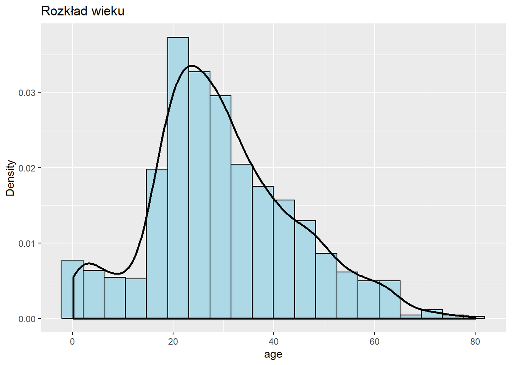

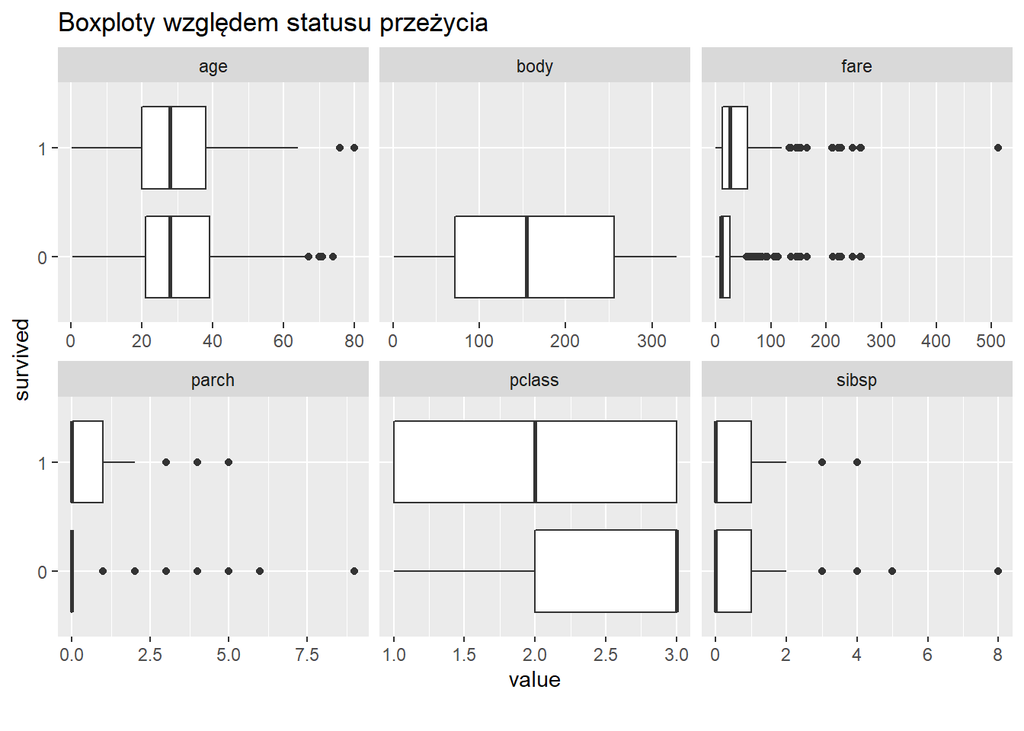

Widzimy, że statystyki nie dają nam zbyt dużo informacji, gdyż w kilku kolumnach mamy sporo brakujących wartości (NA). Skupmy się zatem na tych brakach danych i na sposobach radzenia sobie z nimi.

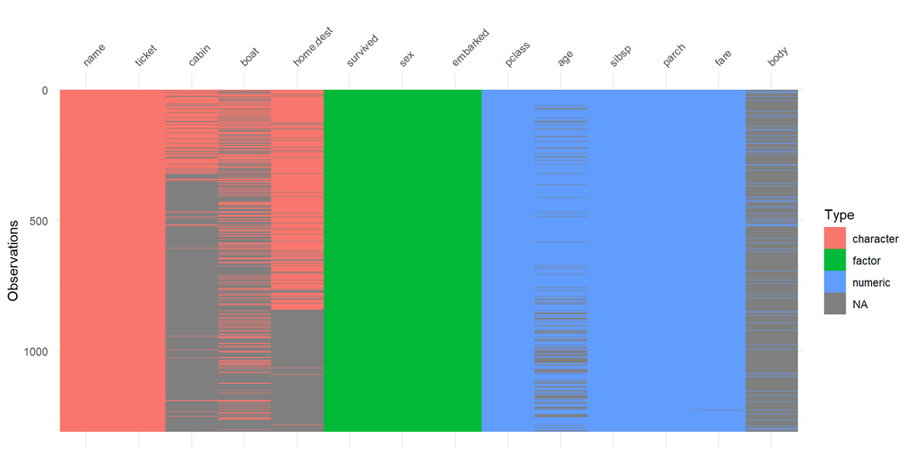

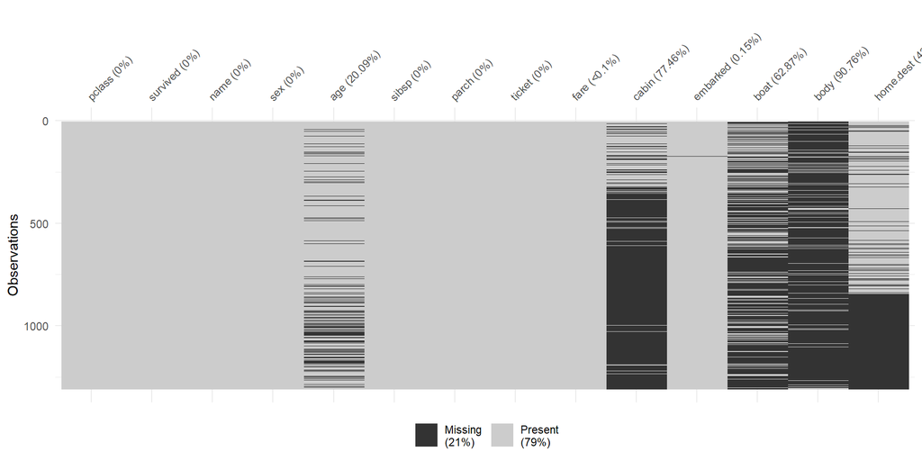

O ile powyższy wykres prezentuje nam ile procentowo obserwacji brakuje w każdej kolumnie, o tyle nie widać tej wartości dla ostatniej z nich, **home.dest**. Zobaczmy zatem to samo podsumowanie, lecz w postaci tabeli.

```
## # A tibble: 14 x 3
##    variable  n_miss pct_miss
##    <chr>      <int>    <dbl>
##  1 body        1188  90.8
##  2 cabin       1014  77.5
##  3 boat         823  62.9
##  4 home.dest    564  43.1
##  5 age          263  20.1
##  6 embarked       2   0.153
##  7 fare           1   0.0764
##  8 pclass         0   0
##  9 survived       0   0
## 10 name           0   0
## 11 sex            0   0
## 12 sibsp          0   0
## 13 parch          0   0
## 14 ticket         0   0
```

Mamy aż 3 kolumny, w których braki danych stanowią ponad 60% - te zmienne nie będą zatem prawdopodobnie zbyt znaczące dla naszej dalszej pracy.

Zobaczmy jednak jak te braki danych prezentują się “z drugiej strony” - tzn. patrząc z “perspektywy” wierszy (obserwacji).

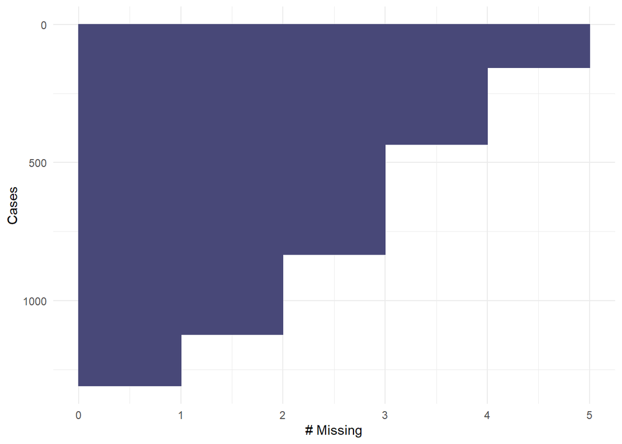

Okazuje się, że nie ma takiej obserwacji, która nie miałaby żadnego braku danych. Widać to także na poniższym wykresie, który pokazuje nam wszystkie “kombinacje” naszych braków danych. Z tego powodu nie będziemy raczej rozważać usuwania rzędów jako techniki imputacji danych.

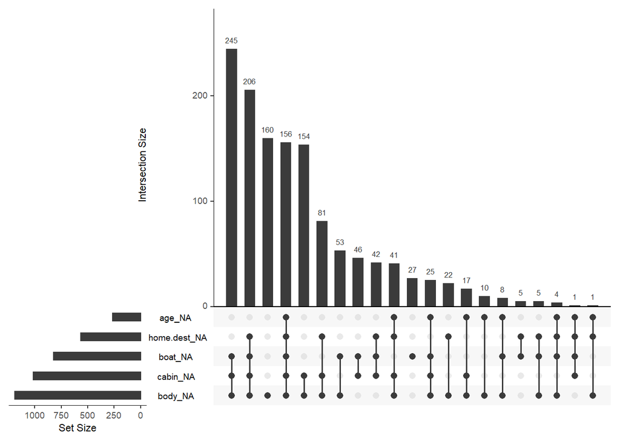

## Imputacja

Jak widać na powyższych wykresach w zmiennych “body”, “cabin” oraz “boat” brakuje odpowiednio ponad 90%, 75% oraz 60% wartości - nie pozostaje nam zatem nic innego jak usunąć te kolumny, gdyż uzupełnienie tak dużych braków nie ma zbyt dużego sensu.

Sprawdźmy jak będą wyglądały nasze dane po tej operacji - poniżej widać, że prezentują się one już trochę lepiej.

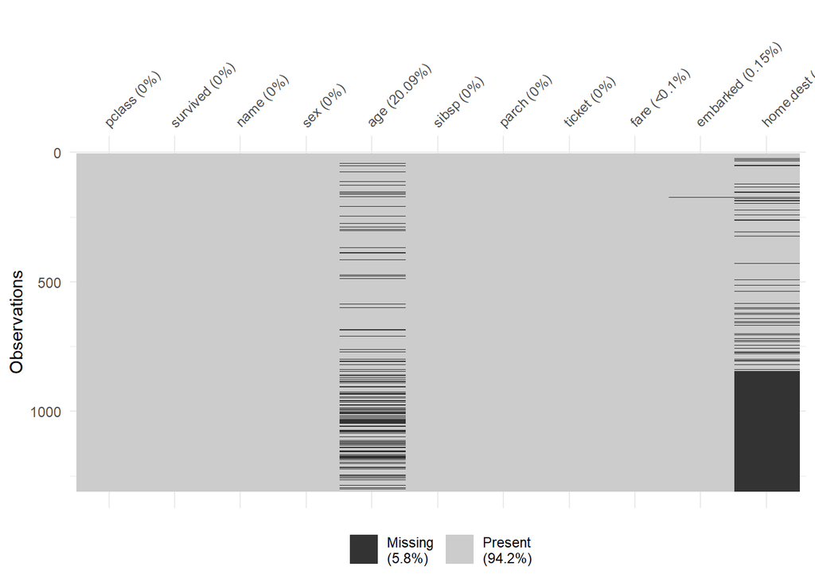

```
## # A tibble: 11 x 3
##    variable  n_miss pct_miss
##    <chr>      <int>    <dbl>
##  1 home.dest    564  43.1
##  2 age          263  20.1
##  3 embarked       2   0.153
##  4 fare           1   0.0764
##  5 pclass         0   0
##  6 survived       0   0
##  7 name           0   0
##  8 sex            0   0
##  9 sibsp          0   0
## 10 parch          0   0
## 11 ticket         0   0
```

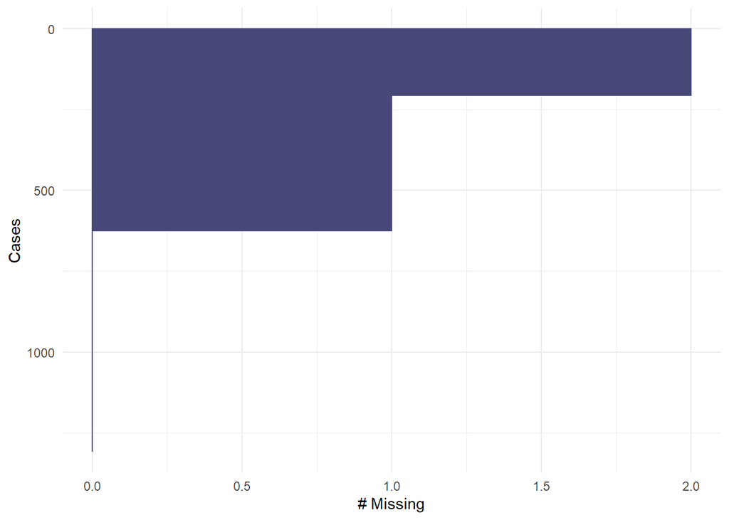

Usunięcie tych trzech kolumn spowodowało, że mamy już całkiem sporo obserwacji z kompletem danych.

Pozostałe zmienne z brakami danych - **age**, **embarked** oraz **fare** uzupełnimy za pomocą średniej, mediany lub mody. Co do zmiennej **home.dest**, prawdopodobnie również będziemy musieli ją usunąć.

Dalszą imputację wykonamy jednak dopiero po podziale zbioru na treningowy i testowy.

## Trenowanie modelu

Zastosujemy algorytm wyszukiwania k najbliższych sąsiadów (kNN). Przewiduje on klasę nowej obserwacji na podstawie k najbliższych obserwacji z próby uczącej. Stosowana jest reguła większościowa.

### Zdefiniowanie rodzaju problemu (task)

```r
# zamieniamy zmienne typu factor
titanic$sex <- as.numeric(as.factor(titanic$sex))
titanic$embarked <- as.numeric(as.factor(titanic$embarked))

# nie będziemy korzystali z "name" oraz "ticket" - są to zmienne typu "char", unikalne dla każdego pasażera
# na potrzeby modelu musimy równiez usunąć "home.dest"
titanic <- titanic%>%
  select(-(name), -(ticket),-(home.dest))

# traget - kolumna, ktora objasniamy
# TaskClassif do problemu klasyfikacji
task_titanic = TaskClassif$new(id = "titanic", backend = titanic, target = "survived")

# podsumowanie zbioru danych
print(task_titanic)
```

```
## <TaskClassif:titanic> (1309 x 8)
## * Target: survived
## * Properties: twoclass
## * Features (7):
##   - dbl (7): age, embarked, fare, parch, pclass, sex, sibsp
```

### Podział na zbiór testowy i treningowy

Do zbioru treningowego bierzemy losowe 80% obserwacji z naszego zbioru danych. Zbiór testowy będą stanowiły pozostałe obserwacje (20%).

```r
# definiujemy, które wiersze należą do zbioru treningowego, a które do testowego
train_set = sample(task_titanic$nrow, 0.8 * task_titanic$nrow)
test_set = setdiff(seq_len(task_titanic$nrow), train_set)

data_train <- titanic[train_set,]
data_test <- titanic[test_set,]
```

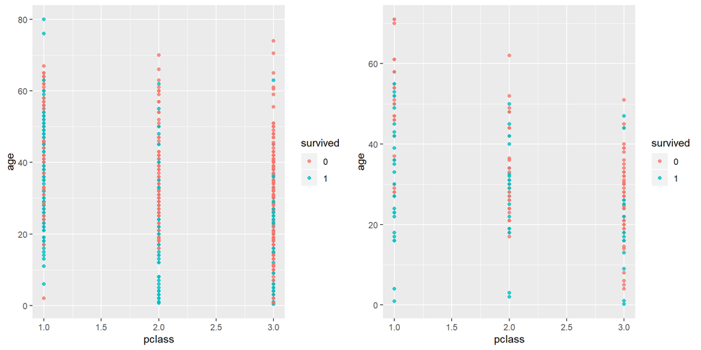

### Imputacja - metoda 1

Braki danych w kolumnach **age** oraz **fare** (jeśli się pojawią) uzupełnimy średnią, w kolumnie **embarked** - modą.

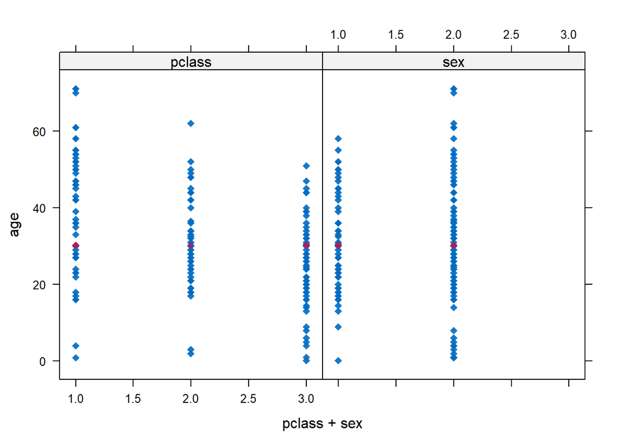

```r
data_train1 <- data_train

# miss_var_summary(data_train1)

imp <- mice(data_train1%>%select(-(embarked)), method = "mean", m = 1, maxit = 1)

data_train1$embarked <- with(data_train1[,-2], impute(embarked, dominant))

data_train1[,-10] <- complete(imp)

# miss_var_summary(data_train1)

# ---------------------------------------------------------------------------------------

data_test1 <- data_test

# miss_var_summary(data_test1)

imp <- mice(data_test1%>%select(-(embarked)), method = "mean", m = 1, maxit = 1)

data_test1$embarked <- with(data_test1[,-2], impute(embarked, dominant))

data_test1[,-10] <- complete(imp)

# miss_var_summary(data_test1)
```

#### Model:

```r
knn_classifier <- knn(train=data_train1[, -2],
                      cl=data_train1$survived,
                      test=data_test1[, -2],
                      k=10,
                      use.all=TRUE)
```

#### Macierz błędów:

```
##          Prediction
## Reference   0   1
##         0 131  38
##         1  49  44
```

#### Accuracy:

```
## [1] 0.6679389
```

### Imputacja - metoda 2

Braki danych w kolumnach **age** oraz **fare** (jeśli się pojawią) uzupełnimy medianą, w kolumnie **embarked** - modą.

```r
data_train2 <- data_train

# miss_var_summary(data_train2)

data_train2$embarked <- with(data_train2[,-2], impute(embarked, dominant))

data_train2$age <- with(data_train2[,-2], impute(age, median))

data_train2$fare <- with(data_train2[,-2], impute(fare, median))

# miss_var_summary(data_train2)

# -----------------------------------------------------------------------------------

data_test2 <- data_test

# miss_var_summary(data_test2)

data_test2$embarked <- with(data_test2[-2], impute(embarked, dominant))

data_test2$age <- with(data_test2[,-2], impute(age, median))

data_test2$fare <- with(data_test2[-2], impute(fare, median))

# miss_var_summary(data_test2)
```

#### Model:

```r
knn_classifier <- knn(train=data_train2[, -2],
                      cl=data_train2$survived,
                      test=data_test2[, -2],
                      k=10,
                      use.all=TRUE)
```

#### Macierz błędów:

```
##          Prediction
## Reference   0   1
##         0 134  35
##         1  49  44
```

#### Accuracy:

```
## [1] 0.6793893
```

### Imputacja - metoda 3

Przetestujmy imputację poprzez usunięcie wszystkich kolumn zawierających jakiekolwiek braki danych.

```r
# miss_var_summary(titanic)

data_train3 <- data_train%>%select(-(age),-(embarked),-(fare))

data_test3 <- data_test%>%select(-(age),-(embarked),-(fare))
```

#### Model:

```r
knn_classifier <- knn(train=data_train3[, -2],
                      cl=data_train3$survived,
                      test=data_test3[, -2],
                      k=10,
                      use.all=TRUE)
```

#### Macierz błędów:

```
##          Prediction
## Reference   0   1
##         0 136  33
##         1  24  69
```

#### Accuracy:

```
## [1] 0.7824427
```

### Imputacja - metoda 4

Przetestujmy imputację poprzez usunięcie wszystkich wierszy zawierających jakiekolwiek braki danych.

```r
# miss_var_summary(titanic)

data_train4 <- na.omit(data_train)

data_test4 <- na.omit(data_test)
```

#### Model:

```r
knn_classifier <- knn(train=data_train4[, -2],
                      cl=data_train4$survived,
                      test=data_test4[, -2],
                      k=10,
                      use.all=TRUE)
```

#### Macierz błędów:

```
##          Prediction
## Reference  0  1
##         0 89 34
##         1 46 34
```

#### Accuracy:

```
## [1] 0.6059113
```